# Crosslinguistic Analysis

Bodo Winter

9/10/2018

## Preprocessing

First, load in data and packages:

```r
# Packages:

library(brms)
library(tidyverse)
library(reshape2)
library(effsize)

# Data:

asym <- read_csv('../data/asymmetry.csv')
SUBTL <- read_csv('../data/SUBTLEX_US.csv') %>%
  rename(Freq = FREQcount) %>%
  select(Word, Freq)
conc <- read_csv('../data/brysbaert_concreteness.csv') %>%
  rename(Conc = Conc.M) %>%
  select(Word, Conc)

# Google data (third analysis):

ngrams <- read_csv('../data/google_ngram_all_langs.csv')
goo <- read_csv('../data/asymmetry_121_google_translations.csv',
                col_names = FALSE) %>%
  rename(Language = X1, Lang_code = X2, Word = X3,
         Translation = X4, BackTranslation = X5)

# Data 2 (suggestions by reviewer 1):

prev <- read_csv('../data/brysbaert_prevalence.csv')
```

Load the COCA data, which also includes the BNC.

This dataset will NOT be put into the repository as it is proprietary (please see https://corpus.byu.edu/ for how to acquire this data. So, if you want to knit the full document, use eval = FALSE or comment the following sections.

```r
COCA <- read_csv('../data/COCA_freqs.csv')
```

Get the sum of frequency per lemma:

```r
COCA <- COCA %>% group_by(L1) %>%
  summarize(coca_spok = sum(coca_spok),
            coca_fic = sum(coca_fic),
            coca_mag = sum(coca_mag),
            coca_news = sum(coca_news),
            coca_acad = sum(coca_acad),
            bnc_spok = sum(bnc_spok),
            bnc_fic = sum(bnc_fic),
            bnc_mag = sum(bnc_mag),
            bnc_news = sum(bnc_news),
            bnc_acad = sum(bnc_acad),
            bnc_misc = sum(bnc_misc))

# Check:

COCA
```

```
## # A tibble: 63,149 x 12
##    L1    coca_spok coca_fic coca_mag coca_news coca_acad bnc_spok bnc_fic
##  * <chr>     <dbl>    <dbl>    <dbl>     <dbl>     <dbl>    <dbl>   <dbl>
##  1 '        109092    83239   131138    192478    124214     4395  230798
##  2 's       295926   474454   577126    639009    453177    16463   74364
##  3 a       2299189  2306052  2673081   2494510   2050192   216459  398983
##  4 a-bo…        17       16       42        32        14        0       1
##  5 a-ha         43        8       10         8         4        0       2
##  6 a-ho…         2        5       15         1         0        0       0
##  7 a-li…        15        1       36        14         1        0       0
##  8 a-ta…         0       13        5         0         0        0       0
##  9 a-te…        21       11       20        29         5        0       0
## 10 a-to…         1        1       14         8         1        0       0
## # … with 63,139 more rows, and 4 more variables: bnc_mag <dbl>, bnc_news <dbl>,
## #   bnc_acad <dbl>, bnc_misc <dbl>
```

Show the asymmetry dataset:

```r
asym
```

```
## # A tibble: 158 x 16
##       ID PairName IsLikeTest HasSomethingToD… Source Symmetry ConceptType
##    <dbl> <chr>    <chr>      <chr>            <chr>  <chr>    <chr>
##  1     1 cloud~f… yes        yes              urban… asymmet… unmarked
##  2     1 cloud~f… yes        yes              urban… asymmet… marked
##  3     2 sun~moon yes        yes              urban… asymmet… unmarked
##  4     2 sun~moon yes        yes              urban… asymmet… marked
##  5     3 grass~s… yes        yes              urban… asymmet… unmarked
##  6     3 grass~s… yes        yes              urban… asymmet… marked
##  7     4 smoke~f… yes        no               urban… asymmet… unmarked
##  8     4 smoke~f… yes        no               urban… asymmet… marked
##  9     5 steam~f… yes        no               urban… asymmet… unmarked
## 10     5 steam~f… yes        no               urban… asymmet… marked
## # … with 148 more rows, and 9 more variables: ConceptComplete <chr>,
## #   Word <chr>, Type <chr>, Transfer <chr>, TransferSimplified <chr>,
## #   Polysemy <dbl>, OvertMarking <dbl>, OvertMarkingReverse <dbl>,
## #   AllLanguagesRelated <dbl>
```

```r
asym <- filter(asym, Symmetry == 'asymmetrical')
```

Explanation: “Unmarked” = source; “marked” = target.

## Merge concreteness and frequency into tibble

For words with multiple translational equivalents, we should compute the average concreteness. Words with translational equivalents can be detected via the presence of “/”.

```r
# Initialize empty column:

asym$Conc <- as.numeric(rep(NA, nrow(asym)))

# Loop through and fill column with matches:

for (i in 1:nrow(asym)) {
  complete_concept <- asym[i, ]$ConceptComplete
  if (str_detect(complete_concept, '/')) {
    these_words <- unlist(str_split(complete_concept, '/'))
    asym[i, ]$Conc <- mean(conc[match(these_words, conc$Word), ]$Conc,
                           na.rm = TRUE)
  } else {
    asym[i, ]$Conc <- conc[match(complete_concept, conc$Word), ]$Conc
  }
}
```

Do the same one for frequency (SUBTLEX, original analysis):

```r
# Initialize empty column:

asym$Freq <- as.numeric(rep(NA, nrow(asym)))

# Loop through and fill column with matches:

for (i in 1:nrow(asym)) {
  complete_concept <- asym[i, ]$ConceptComplete
  if (str_detect(complete_concept, '/')) {
    these_words <- unlist(str_split(complete_concept, '/'))
    asym[i, ]$Freq <- mean(SUBTL[match(these_words, SUBTL$Word), ]$Freq,
                           na.rm = TRUE)
  } else {
    asym[i, ]$Freq <- SUBTL[match(complete_concept, SUBTL$Word), ]$Freq
  }
}
```

Do the same for word prevalence:

```r
# Initialize empty column:

asym$prev <- as.numeric(rep(NA, nrow(asym)))

# Loop through and fill column with matches:

for (i in 1:nrow(asym)) {
  complete_concept <- asym[i, ]$ConceptComplete
  if (str_detect(complete_concept, '/')) {
    these_words <- unlist(str_split(complete_concept, '/'))
    asym[i, ]$prev <- mean(prev[match(these_words, prev$Word), ]$Prevalence,
                           na.rm = TRUE)
  } else {
    asym[i, ]$prev <- prev[match(complete_concept, prev$Word), ]$Prevalence
  }
}
```

Do the same for COCA spoken (based on R1’s suggestion):

```r
# Initialize empty column:

asym$coca_spok <- as.numeric(rep(NA, nrow(asym)))

# Loop through and fill column with matches:

for (i in 1:nrow(asym)) {
  complete_concept <- asym[i, ]$ConceptComplete
  if (str_detect(complete_concept, '/')) {
    these_words <- unlist(str_split(complete_concept, '/'))
    asym[i, ]$coca_spok <- mean(COCA[match(these_words, COCA$L1), ]$coca_spok,
                           na.rm = TRUE)
  } else {
    asym[i, ]$coca_spok <- COCA[match(complete_concept, COCA$L1), ]$coca_spok
  }
}
```

How many concepts do we have concreteness data for?

```r
nrow(filter(asym, !is.na(Conc)))
```

```
## [1] 132
```

```r
nrow(asym)
```

```
## [1] 142
```

```r
nrow(filter(asym, !is.na(Conc))) / nrow(asym)
```

```
## [1] 0.9295775
```

132 out of 142, that’s 93%.

What about frequency?

```r
nrow(filter(asym, !is.na(Freq)))
```

```
## [1] 134
```

```r
nrow(asym)
```

```
## [1] 142
```

```r
nrow(filter(asym, !is.na(Freq))) / nrow(asym)
```

```
## [1] 0.943662
```

134 out of 142, that’s 94%.

Now that we have checked this for frequency, we can set all NAs for frequency to 0, since these are truly not attested in SUBTLEX.

```r
asym <- mutate(asym,
               Freq = ifelse(is.na(Freq), 0, Freq),
               coca_spok = ifelse(is.na(coca_spok), 0, coca_spok))
```

Log transform SUBTLEX frequency after adding +1 for the zeroes (which would otherwise yield infinite values):

```r
asym <- mutate(asym,
               LogFreq = log10(Freq + 1),
               LogCoca = log10(coca_spok + 1))
```

## Concreteness

Compute the descriptive stats for concreteness:

```r
asym %>%
  group_by(ConceptType) %>%
  summarize(Conc.M = mean(Conc, na.rm = TRUE),
    Conc.SD = sd(Conc, na.rm = TRUE))
```

```
## # A tibble: 2 x 3
##   ConceptType Conc.M Conc.SD
## * <chr>        <dbl>   <dbl>
## 1 marked        4.68   0.434
## 2 unmarked      4.74   0.279
```

Compute effect size for concreteness:

```r
# Find pairs that have an NA which we can't use for paired Cohen's d:

these_pairs <- asym[is.na(asym$Conc), ]$PairName

# Compute Cohen's d for this data:

cohen.d(Conc ~ ConceptType,
        data = filter(asym,
                      !(PairName %in% these_pairs)),
        paired = TRUE)
```

```
##
## Cohen's d
##
## d estimate: -0.2046491 (small)
## 95 percent confidence interval:
##      lower      upper
## -0.5144351  0.1051369
```

```r
# Save Cohen's d value for plotting later:

conc_d <- cohen.d(Conc ~ ConceptType,
                  data = filter(asym,
                                !(PairName %in% these_pairs)),
                  paired = TRUE)$estimate
```

Perform t-test:

```r
t.test(Conc ~ ConceptType,
       data = filter(asym,
                     !(PairName %in% these_pairs)),
       paired = TRUE)
```

```
##
##  Paired t-test
##
## data:  Conc by ConceptType
## t = -1.3214, df = 61, p-value = 0.1913
## alternative hypothesis: true difference in means is not equal to 0
## 95 percent confidence interval:
##  -0.1905237  0.0389108
## sample estimates:
## mean of the differences
##             -0.07580645
```

Compute for how many pairs there was a frequency difference.

```r
source_concs <- asym[rep(c(TRUE, FALSE), nrow(asym) / 2), ]$Conc
target_concs <- asym[rep(c(FALSE, TRUE), nrow(asym) / 2), ]$Conc
conc_diffs <- source_concs - target_concs

sum(conc_diffs > 0, na.rm = TRUE) # how many is this the case
```

```
## [1] 35
```

```r
length(conc_diffs[!is.na(conc_diffs)]) # out of how many
```

```
## [1] 62
```

```r
sum(conc_diffs > 0, na.rm = TRUE) / length(conc_diffs[!is.na(conc_diffs)])
```

```
## [1] 0.5645161
```

## Frequency

**Note:** Our original analysis was with SUBTLEX, but R1 convinced us to report COCA instead. This is kept in here for continuity with the previous version to clarify how things have changed throughout the review process.

Compute the descriptive stats for SUBTLEX frequency:

```r
asym %>%
  group_by(ConceptType) %>%
  summarize(Freq = mean(Freq, na.rm = TRUE),
            LogFreq.M = mean(LogFreq, na.rm = TRUE),
            LogFreq.SD = sd(LogFreq, na.rm = TRUE))
```

```
## # A tibble: 2 x 4
##   ConceptType  Freq LogFreq.M LogFreq.SD
## * <chr>       <dbl>     <dbl>      <dbl>
## 1 marked       817.      2.41      0.946
## 2 unmarked    5761.      3.14      0.912
```

Compute effect size for SUBTLEX frequency:

```r
# Compute Cohen's d for this data:

cohen.d(LogFreq ~ ConceptType,
        data = asym,
        paired = TRUE)
```

```
##
## Cohen's d
##
## d estimate: -0.7915799 (medium)
## 95 percent confidence interval:
##      lower      upper
## -1.1251111 -0.4580487
```

```r
# Save Cohen's d value for plotting later:

freq_d <- cohen.d(LogFreq ~ ConceptType,
                  data = asym,
                  paired = TRUE)$estimate
```

Perform t-test:

```r
t.test(Freq ~ ConceptType,
       data = asym,
       paired = TRUE)
```

```
##
##  Paired t-test
##
## data:  Freq by ConceptType
## t = -4.0735, df = 70, p-value = 0.0001204
## alternative hypothesis: true difference in means is not equal to 0
## 95 percent confidence interval:
##  -7364.632 -2523.349
## sample estimates:
## mean of the differences
##               -4943.991
```

Compute for how many pairs there was a frequency difference.

```r
source_freqs <- asym[rep(c(TRUE, FALSE), nrow(asym) / 2), ]$LogFreq
target_freqs <- asym[rep(c(FALSE, TRUE), nrow(asym) / 2), ]$LogFreq
freq_diffs <- source_freqs - target_freqs

sum(freq_diffs > 0, na.rm = TRUE) # how many is this the case
```

```
## [1] 52
```

```r
length(freq_diffs[!is.na(freq_diffs)]) # out of how many
```

```
## [1] 71
```

```r
sum(freq_diffs > 0, na.rm = TRUE) / length(freq_diffs[!is.na(freq_diffs)])
```

```
## [1] 0.7323944
```

## R1 suggestion: COCA instead of SUBTLEX

```r
asym %>%
  group_by(ConceptType) %>%
  summarize(coca_spok = mean(coca_spok, na.rm = TRUE),
            LogCoca_M = mean(LogCoca, na.rm = TRUE),
            LogCoca_SD = sd(LogCoca, na.rm = TRUE))
```

```
## # A tibble: 2 x 4
##   ConceptType coca_spok LogCoca_M LogCoca_SD
## * <chr>           <dbl>     <dbl>      <dbl>
## 1 marked          1277.      2.41       1.13
## 2 unmarked       12078.      3.29       1.03
```

Compute effect size for COCA frequency:

```r
# Compute Cohen's d for this data:

cohen.d(LogCoca ~ ConceptType,
        data = asym,
        paired = TRUE)
```

```
##
## Cohen's d
##
## d estimate: -0.809236 (large)
## 95 percent confidence interval:
##      lower      upper
## -1.1438724 -0.4745996
```

```r
# Save Cohen's d value for plotting later:

freq_d <- cohen.d(LogCoca ~ ConceptType,
                  data = asym,
                  paired = TRUE)$estimate
```

Perform t-test:

```r
t.test(LogCoca ~ ConceptType,
       data = asym,
       paired = TRUE)
```

```
##
##  Paired t-test
##
## data:  LogCoca by ConceptType
## t = -5.5084, df = 70, p-value = 5.637e-07
## alternative hypothesis: true difference in means is not equal to 0
## 95 percent confidence interval:
##  -1.1913482 -0.5579705
## sample estimates:
## mean of the differences
##              -0.8746593
```

Compute for how many pairs there was a frequency difference.

```r
source_freqs <- asym[rep(c(TRUE, FALSE), nrow(asym) / 2), ]$LogCoca
target_freqs <- asym[rep(c(FALSE, TRUE), nrow(asym) / 2), ]$LogCoca
freq_diffs <- source_freqs - target_freqs

sum(freq_diffs > 0, na.rm = TRUE) # how many is this the case
```

```
## [1] 50
```

```r
length(freq_diffs[!is.na(freq_diffs)]) # out of how many
```

```
## [1] 71
```

```r
sum(freq_diffs > 0, na.rm = TRUE) / length(freq_diffs[!is.na(freq_diffs)])
```

```
## [1] 0.7042254
```

## R1 suggestion: Prevalence

```r
asym %>%
  group_by(ConceptType) %>%
  summarize(prev.M = mean(prev, na.rm = TRUE),
            prev.SD = sd(prev, na.rm = TRUE))
```

```
## # A tibble: 2 x 3
##   ConceptType prev.M prev.SD
## * <chr>        <dbl>   <dbl>
## 1 marked        2.34   0.163
## 2 unmarked      2.40   0.135
```

```r
# Find pairs that have an NA which we can't use for paired Cohen's d:

these_pairs <- asym[is.na(asym$prev), ]$PairName

# Compute Cohen's d for this data:

cohen.d(prev ~ ConceptType,
        data = filter(asym,
                      !(PairName %in% these_pairs)),
        paired = TRUE)
```

```
##
## Cohen's d
##
## d estimate: -0.3879349 (small)
## 95 percent confidence interval:
##       lower       upper
## -0.76574221 -0.01012763
```

```r
# Save Cohen's d value for plotting later:

prev_d <- cohen.d(prev ~ ConceptType,
                  data = filter(asym,
                                !(PairName %in% these_pairs)),
                  paired = TRUE)$estimate
```

Perform t-test:

```r
t.test(prev ~ ConceptType,
       data = filter(asym,
                     !(PairName %in% these_pairs)),
       paired = TRUE)
```

```
##
##  Paired t-test
##
## data:  prev by ConceptType
## t = -2.1078, df = 61, p-value = 0.03917
## alternative hypothesis: true difference in means is not equal to 0
## 95 percent confidence interval:
##  -0.112993083 -0.002974659
## sample estimates:
## mean of the differences
##             -0.05798387
```

Compute for how many pairs there was a frequency difference.

```r
source_concs <- asym[rep(c(TRUE, FALSE), nrow(asym) / 2), ]$prev
target_concs <- asym[rep(c(FALSE, TRUE), nrow(asym) / 2), ]$prev
prev_diffs <- source_concs - target_concs

sum(prev_diffs > 0, na.rm = TRUE) # how many is this the case
```

```
## [1] 32
```

```r
length(prev_diffs[!is.na(prev_diffs)]) # out of how many
```

```
## [1] 62
```

```r
sum(prev_diffs > 0, na.rm = TRUE) / length(prev_diffs[!is.na(prev_diffs)])
```

```
## [1] 0.516129
```

## Extension to other corpora

Get the sum of frequencies per lemma:

```r
COCA <- COCA %>% group_by(L1) %>%
  summarize(coca_spok = sum(coca_spok),
            coca_fic = sum(coca_fic),
            coca_mag = sum(coca_mag),
            coca_news = sum(coca_news),
            coca_acad = sum(coca_acad),
            bnc_spok = sum(bnc_spok),
            bnc_fic = sum(bnc_fic),
            bnc_mag = sum(bnc_mag),
            bnc_news = sum(bnc_news),
            bnc_acad = sum(bnc_acad))

# Check:

COCA
```

```
## # A tibble: 63,149 x 11
##    L1    coca_spok coca_fic coca_mag coca_news coca_acad bnc_spok bnc_fic
##  * <chr>     <dbl>    <dbl>    <dbl>     <dbl>     <dbl>    <dbl>   <dbl>
##  1 '        109092    83239   131138    192478    124214     4395  230798
##  2 's       295926   474454   577126    639009    453177    16463   74364
##  3 a       2299189  2306052  2673081   2494510   2050192   216459  398983
##  4 a-bo…        17       16       42        32        14        0       1
##  5 a-ha         43        8       10         8         4        0       2
##  6 a-ho…         2        5       15         1         0        0       0
##  7 a-li…        15        1       36        14         1        0       0
##  8 a-ta…         0       13        5         0         0        0       0
##  9 a-te…        21       11       20        29         5        0       0
## 10 a-to…         1        1       14         8         1        0       0
## # … with 63,139 more rows, and 3 more variables: bnc_mag <dbl>, bnc_news <dbl>,
## #   bnc_acad <dbl>
```

Do the same looping business as above for matching (taking averages for translational equivalents):

```r
# Initialize empty column:

asym$COCA_spok <- as.numeric(rep(NA, nrow(asym)))
asym$COCA_fic <- as.numeric(rep(NA, nrow(asym)))
asym$COCA_mag <- as.numeric(rep(NA, nrow(asym)))
asym$COCA_news <- as.numeric(rep(NA, nrow(asym)))
asym$COCA_acad <- as.numeric(rep(NA, nrow(asym)))
asym$BNC_spok <- as.numeric(rep(NA, nrow(asym)))
asym$BNC_fic <- as.numeric(rep(NA, nrow(asym)))
asym$BNC_mag <- as.numeric(rep(NA, nrow(asym)))
asym$BNC_news <- as.numeric(rep(NA, nrow(asym)))
asym$BNC_acad <- as.numeric(rep(NA, nrow(asym)))

# Loop through and fill column with matches:

for (i in 1:nrow(asym)) {
  complete_concept <- asym[i, ]$ConceptComplete
  if (str_detect(complete_concept, '/')) {
    these_words <- unlist(str_split(complete_concept, '/'))

    # COCA:

    asym[i, ]$COCA_spok <- mean(COCA[match(these_words, COCA$L1), ]$coca_spok,
                                na.rm = TRUE)
    asym[i, ]$COCA_fic <- mean(COCA[match(these_words, COCA$L1), ]$coca_fic,
                                na.rm = TRUE)
    asym[i, ]$COCA_mag <- mean(COCA[match(these_words, COCA$L1), ]$coca_mag,
                                na.rm = TRUE)
    asym[i, ]$COCA_news <- mean(COCA[match(these_words, COCA$L1), ]$coca_news,
                                na.rm = TRUE)
    asym[i, ]$COCA_acad <- mean(COCA[match(these_words, COCA$L1), ]$coca_acad,
                                na.rm = TRUE)

    # BNC:

    asym[i, ]$BNC_spok <- mean(COCA[match(these_words, COCA$L1), ]$bnc_spok,
                                na.rm = TRUE)
    asym[i, ]$BNC_fic <- mean(COCA[match(these_words, COCA$L1), ]$bnc_fic,
                                na.rm = TRUE)
    asym[i, ]$BNC_mag <- mean(COCA[match(these_words, COCA$L1), ]$bnc_mag,
                                na.rm = TRUE)
    asym[i, ]$BNC_news <- mean(COCA[match(these_words, COCA$L1), ]$bnc_news,
                                na.rm = TRUE)
    asym[i, ]$BNC_acad <- mean(COCA[match(these_words, COCA$L1), ]$bnc_acad,
                                na.rm = TRUE)

  } else {
    # COCA:

    asym[i, ]$COCA_spok <- COCA[match(complete_concept, COCA$L1), ]$coca_spok
    asym[i, ]$COCA_fic <- COCA[match(complete_concept, COCA$L1), ]$coca_fic
    asym[i, ]$COCA_mag <- COCA[match(complete_concept, COCA$L1), ]$coca_mag
    asym[i, ]$COCA_news <- COCA[match(complete_concept, COCA$L1), ]$coca_news
    asym[i, ]$COCA_acad <- COCA[match(complete_concept, COCA$L1), ]$coca_acad

    # BNC:

    asym[i, ]$BNC_spok <- COCA[match(complete_concept, COCA$L1), ]$bnc_spok
    asym[i, ]$BNC_fic <- COCA[match(complete_concept, COCA$L1), ]$bnc_fic
    asym[i, ]$BNC_mag <- COCA[match(complete_concept, COCA$L1), ]$bnc_mag
    asym[i, ]$BNC_news <- COCA[match(complete_concept, COCA$L1), ]$bnc_news
    asym[i, ]$BNC_acad <- COCA[match(complete_concept, COCA$L1), ]$bnc_acad

  }
}
```

Set NAs to zero since these are actually not attested:

```r
asym <- mutate(asym,
               COCA_spok = ifelse(is.na(COCA_spok), 0, COCA_spok),
               COCA_fic = ifelse(is.na(COCA_fic), 0, COCA_fic),
               COCA_mag = ifelse(is.na(COCA_mag), 0, COCA_mag),
               COCA_news = ifelse(is.na(COCA_news), 0, COCA_news),
               COCA_acad = ifelse(is.na(COCA_acad), 0, COCA_acad),
               BNC_spok = ifelse(is.na(BNC_spok), 0, BNC_spok),
               BNC_fic = ifelse(is.na(BNC_fic), 0, BNC_fic),
               BNC_mag = ifelse(is.na(BNC_mag), 0, BNC_mag),
               BNC_news = ifelse(is.na(BNC_news), 0, BNC_news),
               BNC_acad = ifelse(is.na(BNC_news), 0, BNC_news))
```

Compute log frequencies (+1 because of 0’s):

```r
asym <- mutate(asym,
               COCA_spok = log10(COCA_spok + 1),
               COCA_fic = log10(COCA_fic + 1),
               COCA_mag = log10(COCA_mag + 1),
               COCA_news = log10(COCA_news + 1),
               COCA_acad = log10(COCA_acad + 1),
               BNC_spok = log10(BNC_spok + 1),
               BNC_fic = log10(BNC_fic + 1),
               BNC_mag = log10(BNC_mag + 1),
               BNC_news = log10(BNC_news + 1),
               BNC_acad = log10(BNC_acad + 1))
```

Compute averages:

```r
asym %>% group_by(ConceptType) %>%
  summarize(COCA_spok = mean(COCA_spok),
            COCA_fic = mean(COCA_fic),
            COCA_mag = mean(COCA_mag),
            COCA_news = mean(COCA_news),
            COCA_acad = mean(COCA_acad),
            BNC_spok = mean(BNC_spok),
            BNC_fic = mean(BNC_fic),
            BNC_mag = mean(BNC_mag),
            BNC_news = mean(BNC_news),
            BNC_acad = mean(BNC_acad)) %>% print(width = Inf)
```

```
## # A tibble: 2 x 11
##   ConceptType COCA_spok COCA_fic COCA_mag COCA_news COCA_acad BNC_spok BNC_fic
## * <chr>           <dbl>    <dbl>    <dbl>     <dbl>     <dbl>    <dbl>   <dbl>
## 1 marked           2.41     2.96     2.85      2.59      2.49     1.63    2.22
## 2 unmarked         3.29     3.83     3.69      3.43      3.27     2.38    3.04
##   BNC_mag BNC_news BNC_acad
## *   <dbl>    <dbl>    <dbl>
## 1    1.78     1.80     1.80
## 2    2.50     2.51     2.51
```

Check Cohen’s d for all of these comparisons:

```r
all_cols <- c('spok', 'fic', 'mag', 'news', 'acad')
all_cols <- c(str_c('COCA_', all_cols),
              str_c('BNC_', all_cols))

# Check:

all_cols
```

```
##  [1] "COCA_spok" "COCA_fic"  "COCA_mag"  "COCA_news" "COCA_acad" "BNC_spok"
##  [7] "BNC_fic"   "BNC_mag"   "BNC_news"  "BNC_acad"
```

```r
# Initialize vector t be filled with Cohen's d's as well as p-values:

all_ds <- rep(NA, length(all_cols))
all_ps <- rep(NA, length(all_cols))

# Loop through and compute Cohen's d:

for (i in seq_along(all_cols)) {
  my_formula <- as.formula(str_c(all_cols[i], ' ~ ConceptType'))
  all_ds[i] <- cohen.d(my_formula, data = asym,
                       paired = TRUE)$estimate
  all_ps[i] <- t.test(my_formula, data = asym,
                      paired = TRUE, var.equal = TRUE)$p.val
}
```

Check Cohen’s d:

```r
round(all_ds, 2)
```

```
##  [1] -0.81 -0.76 -0.75 -0.75 -0.75 -0.86 -0.84 -0.83 -0.76 -0.76
```

Check significances:

```r
all(all_ps < 0.05) # all significant
```

```
## [1] TRUE
```

```r
# Correcting for performing 10 tests:

all(p.adjust(all_ps, method = 'bonferroni', n = length(all_cols)) < 0.05)
```

```
## [1] TRUE
```

For all corpora there is a significant difference, even after correcting for performing 10 tests.

Put them into a tibble for reporting:

```r
tibble(Corpus = all_cols,
       d = all_ds,
       p.val = all_ps) %>%
  arrange(d)
```

```
## # A tibble: 10 x 3
##    Corpus         d        p.val
##    <chr>      <dbl>        <dbl>
##  1 BNC_spok  -0.864 0.000000195
##  2 BNC_fic   -0.841 0.0000000931
##  3 BNC_mag   -0.835 0.000000368
##  4 COCA_spok -0.809 0.000000564
##  5 BNC_news  -0.762 0.00000438
##  6 BNC_acad  -0.762 0.00000438
##  7 COCA_fic  -0.761 0.000000682
##  8 COCA_mag  -0.752 0.00000103
##  9 COCA_acad -0.751 0.00000120
## 10 COCA_news -0.749 0.00000203
```

## Google Ngram cross-linguistic analysis

Create a copy of the data frame:

```r
goo_asym <- asym
```

Process the Google ngram data. Get only the data after 1980:

```r
ngrams <- filter(ngrams, Year > 1980)
```

Create unique word identifiers (for a few of the Romance languages it may be the same):

```r
ngrams <- mutate(ngrams,
                 UniquePhrase = str_c(Phrase, ':', Language))
```

Average by unique phrase:

```r
ngram_means <- ngrams %>%
  group_by(UniquePhrase, Phrase, Language) %>%
  summarize(Frequency = mean(Frequency))
```

Link back to English phrase:

```r
goo <- mutate(goo,
              UniquePhrase = str_c(Translation, ':', Language))
ngram_means <- left_join(ngram_means, goo)
```

Fix the English bits:

```r
# Row identifier:

english <- ngram_means$Language == 'English'

ngram_means[english, ]$Lang_code <- 'eng'
ngram_means[english, ]$Word <- ngram_means[english, ]$Phrase
ngram_means[english, ]$Translation <- ngram_means[english, ]$Phrase
```

Merge asymmetry data into there:

```r
langs <- unique(ngram_means$Language)
freqs <- matrix(numeric(length(langs) * nrow(goo_asym)), nrow = nrow(goo_asym))
for (i in seq_along(langs)) {
  this_df <- filter(ngram_means, Language == langs[i])
  freqs[, i] <- this_df[match(goo_asym$Word, this_df$Word), ]$Frequency
    }
colnames(freqs) <- langs
colnames(freqs)[ncol(freqs)] <- 'Chinese'
langs[length(langs)] <- 'Chinese'
```

Log-transform this:

```r
freqs <- apply(freqs, 2, log10)
```

Bind to data frame:

```r
goo_asym <- bind_cols(goo_asym, as.data.frame(freqs))
```

Make into long data for mixed logistic regression analysis:

```r
goo_long <- select(goo_asym,
                   PairName, ConceptType,
                   Italian:Chinese)
goo_long <- melt(goo_long,
                 id.vars = c('PairName', 'ConceptType')) %>%
  rename(Language = variable, Freq = value) %>%
  mutate(Freq_z = Freq - mean(Freq, na.rm = TRUE),
         Freq_z = Freq_z / sd(Freq_z, na.rm = TRUE))
```

Create 0/1 coded response variable:

```r
goo_long <- mutate(goo_long,
                   Concept01 = ifelse(ConceptType == 'unmarked', 1, 0))
```

Weakly informative priors for beta:

```r
my_priors <- c(prior(normal(0, 1), class = b))
```

Use all cores for parallel processing:

```r
options(mc.cores=parallel::detectCores())
```

Control parameters for convergence:

```r
my_controls <- list(adapt_delta = 0.999,
                    max_treedepth = 13)
```

Create the model:

```r
goo_brm <- brm(Concept01 ~ Freq_z +
                 (1 + Freq_z|PairName) +
                 (1 + Freq_z|Language),
               data = goo_long,
               control = my_controls,
               prior = my_priors,
               init = 0,
               family = bernoulli,
               seed = 666,
               iter = 8000, warmup = 4000, chains = 4)
save(goo_brm, file = '../models/goo_brm.RData')
```

Summarize the model:

```r
summary(goo_brm)
```

```
##  Family: bernoulli
##   Links: mu = logit
## Formula: Concept01 ~ Freq_z + (1 + Freq_z | PairName) + (1 + Freq_z | Language)
##    Data: goo_long (Number of observations: 822)
## Samples: 4 chains, each with iter = 8000; warmup = 4000; thin = 1;
##          total post-warmup samples = 16000
##
## Group-Level Effects:
## ~Language (Number of levels: 8)
##                       Estimate Est.Error l-95% CI u-95% CI Rhat Bulk_ESS
## sd(Intercept)             0.62      0.27     0.24     1.29 1.00     5283
## sd(Freq_z)                0.18      0.17     0.01     0.60 1.00     8963
## cor(Intercept,Freq_z)    -0.18      0.57    -0.97     0.91 1.00    18200
##                       Tail_ESS
## sd(Intercept)             7577
## sd(Freq_z)                7688
## cor(Intercept,Freq_z)    11811
##
## ~PairName (Number of levels: 71)
##                       Estimate Est.Error l-95% CI u-95% CI Rhat Bulk_ESS
## sd(Intercept)             1.50      0.27     1.02     2.07 1.00     4704
## sd(Freq_z)                2.40      0.40     1.70     3.27 1.00     5094
## cor(Intercept,Freq_z)     0.10      0.22    -0.33     0.51 1.00     2455
##                       Tail_ESS
## sd(Intercept)             9121
## sd(Freq_z)                8579
## cor(Intercept,Freq_z)     5429
##
## Population-Level Effects:
##           Estimate Est.Error l-95% CI u-95% CI Rhat Bulk_ESS Tail_ESS
## Intercept    -0.09      0.33    -0.76     0.55 1.00     6870     8499
## Freq_z        2.37      0.38     1.66     3.14 1.00     6871     8776
##
## Samples were drawn using sampling(NUTS). For each parameter, Bulk_ESS
## and Tail_ESS are effective sample size measures, and Rhat is the potential
## scale reduction factor on split chains (at convergence, Rhat = 1).
```

Calculate posterior probability of the effect being below zero:

```r
posts <- posterior_samples(goo_brm)
sum(posts$b_Freq_z < 0) / nrow(posts)
```

```
## [1] 0
```

Check for individual languages:

```r
sum((posts$b_Freq_z + posts$`r_Language[Chinese,Freq_z]`) < 0) / nrow(posts)
```

```
## [1] 0
```

```r
sum((posts$b_Freq_z + posts$`r_Language[Hebrew,Freq_z]`) < 0) / nrow(posts)
```

```
## [1] 6.25e-05
```

```r
sum((posts$b_Freq_z + posts$`r_Language[Russian,Freq_z]`) < 0) / nrow(posts)
```

```
## [1] 0
```

```r
sum((posts$b_Freq_z + posts$`r_Language[German,Freq_z]`) < 0) / nrow(posts)
```

```
## [1] 0
```

```r
sum((posts$b_Freq_z + posts$`r_Language[French,Freq_z]`) < 0) / nrow(posts)
```

```
## [1] 0
```

```r
sum((posts$b_Freq_z + posts$`r_Language[English,Freq_z]`) < 0) / nrow(posts)
```

```
## [1] 0
```

```r
sum((posts$b_Freq_z + posts$`r_Language[Spanish,Freq_z]`) < 0) / nrow(posts)
```

```
## [1] 0
```

```r
sum((posts$b_Freq_z + posts$`r_Language[Italian,Freq_z]`) < 0) / nrow(posts)
```

```
## [1] 0
```

## Plot coefficients per language

Create a table that contains all the coefficients. First, get posterior means:

```r
post_means <- c(mean(posts$b_Freq_z + posts$`r_Language[Chinese,Freq_z]`),
                mean(posts$b_Freq_z + posts$`r_Language[English,Freq_z]`),
                mean(posts$b_Freq_z + posts$`r_Language[French,Freq_z]`),
                mean(posts$b_Freq_z + posts$`r_Language[German,Freq_z]`),
                mean(posts$b_Freq_z + posts$`r_Language[Hebrew,Freq_z]`),
                mean(posts$b_Freq_z + posts$`r_Language[Italian,Freq_z]`),
                mean(posts$b_Freq_z + posts$`r_Language[Russian,Freq_z]`),
                mean(posts$b_Freq_z + posts$`r_Language[Spanish,Freq_z]`))
```

Get the lower CIs:

```r
lower_CIs <- c(quantile(posts$b_Freq_z +
                           posts$`r_Language[Chinese,Freq_z]`, 0.025),
                quantile(posts$b_Freq_z +
                           posts$`r_Language[English,Freq_z]`, 0.025),
                quantile(posts$b_Freq_z +
                           posts$`r_Language[French,Freq_z]`, 0.025),
                quantile(posts$b_Freq_z +
                           posts$`r_Language[German,Freq_z]`, 0.025),
                quantile(posts$b_Freq_z +
                           posts$`r_Language[Hebrew,Freq_z]`, 0.025),
                quantile(posts$b_Freq_z +
                           posts$`r_Language[Italian,Freq_z]`, 0.025),
                quantile(posts$b_Freq_z +
                           posts$`r_Language[Russian,Freq_z]`, 0.025),
                quantile(posts$b_Freq_z +
                           posts$`r_Language[Spanish,Freq_z]`, 0.025))
```

Get the upper CIs:

```r
upper_CIs <- c(quantile(posts$b_Freq_z +
                           posts$`r_Language[Chinese,Freq_z]`, 0.975),
                quantile(posts$b_Freq_z +
                           posts$`r_Language[English,Freq_z]`, 0.975),
                quantile(posts$b_Freq_z +
                           posts$`r_Language[French,Freq_z]`, 0.975),
                quantile(posts$b_Freq_z +
                           posts$`r_Language[German,Freq_z]`, 0.975),
                quantile(posts$b_Freq_z +
                           posts$`r_Language[Hebrew,Freq_z]`, 0.975),
                quantile(posts$b_Freq_z +
                           posts$`r_Language[Italian,Freq_z]`, 0.975),
                quantile(posts$b_Freq_z +
                           posts$`r_Language[Russian,Freq_z]`, 0.975),
                quantile(posts$b_Freq_z +
                           posts$`r_Language[Spanish,Freq_z]`, 0.975))
```

List of languages vector:

```r
langs <- c('Chinese', 'English', 'French', 'German', 'Hebrew',
           'Italian', 'Russian', 'Spanish')
```

Put all into a tibble:

```r
plot_posts <- tibble(langs,
                     post_means,
                     lower_CIs,
                     upper_CIs)

# Check:

plot_posts
```

```
## # A tibble: 8 x 4
##   langs   post_means lower_CIs upper_CIs
##   <chr>        <dbl>     <dbl>     <dbl>
## 1 Chinese       2.33      1.56      3.13
## 2 English       2.48      1.71      3.34
## 3 French        2.39      1.65      3.19
## 4 German        2.37      1.63      3.17
## 5 Hebrew        2.34      1.50      3.18
## 6 Italian       2.43      1.69      3.25
## 7 Russian       2.37      1.63      3.18
## 8 Spanish       2.41      1.66      3.23
```

Make a plot of this:

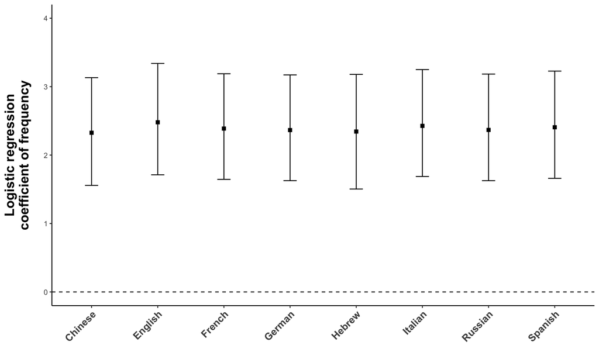

```r
# Main plot aesthetics:

google_p <- plot_posts %>%
  ggplot(mapping = aes(x = langs, y = post_means))

# Add geoms:

google_p <- google_p +
  geom_point(pch = 15, size = 2) +
  geom_errorbar(mapping = aes(ymin = lower_CIs, ymax = upper_CIs),
                width = 0.2) +
  geom_hline(yintercept = 0, linetype = 2)

# Add themes and other specs:

google_p <- google_p +
  theme_classic() +
  xlab('') +
  ylab('Logistic regression\ncoefficient of frequency') +
  theme(axis.text.x = element_text(angle = 45, hjust = 1,
                                   face = 'bold', size = 12),
        axis.title.y = element_text(face = 'bold', size = 16,
                                    margin = margin(t = 0, r = 15,
                                                    b = 0, l = 0)),
        panel.grid.major = element_blank(),
        panel.grid.minor = element_blank()) +
  ylim(c(0, 4))

# Plot:

google_p
```

```r
# Save:

ggsave(filename = '../figures/google_ngram.png', plot = google_p,
       width = 7, height = 5)
ggsave(filename = '../figures/google_ngram.pdf', plot = google_p,
       width = 7, height = 5)
```

## Bayesian logistic regression model comparing frequency with concreteness:

Prepare data for logistic regression analysis:

```r
asym <- mutate(asym,
               Concept01 = ifelse(ConceptType == 'unmarked', 1, 0))
```

Are frequency and concreteness correlated with each other?

```r
with(asym, cor.test(Conc, Freq))
```

```
##
##  Pearson's product-moment correlation
##
## data:  Conc and Freq
## t = -4.1353, df = 130, p-value = 6.319e-05
## alternative hypothesis: true correlation is not equal to 0
## 95 percent confidence interval:
##  -0.4836511 -0.1806059
## sample estimates:
##        cor
## -0.3409562
```

For comparability, z-score both:

```r
asym <- mutate(asym,
               Conc_z = Conc - mean(Conc, na.rm = TRUE),
               Conc_z = Conc_z / sd(Conc_z, na.rm = TRUE),
               LogFreq_z = LogFreq - mean(LogFreq, na.rm = TRUE),
               LogFreq_z = LogFreq_z / sd(LogFreq_z, na.rm = TRUE))
```

Fit the logistic regression model:

```r
my_controls <- list(adapt_delta = 0.999,
                    max_treedepth = 13)

asym_brm <- brm(Concept01 ~ Conc_z + LogFreq_z +
                  (1 + Conc_z + LogFreq_z|PairName),
                data = asym,
                seed = 666,
                init = 0,
                prior = my_priors,
                control = my_controls,
                family = bernoulli(),
                iter = 8000, warmup = 4000, chains = 4)
```

Check model:

```r
summary(asym_brm)
```

```
##  Family: bernoulli
##   Links: mu = logit
## Formula: Concept01 ~ Conc_z + LogFreq_z + (1 + Conc_z + LogFreq_z | PairName)
##    Data: asym (Number of observations: 132)
## Samples: 4 chains, each with iter = 8000; warmup = 4000; thin = 1;
##          total post-warmup samples = 16000
##
## Group-Level Effects:
## ~PairName (Number of levels: 70)
##                          Estimate Est.Error l-95% CI u-95% CI Rhat Bulk_ESS
## sd(Intercept)                0.25      0.20     0.01     0.75 1.00     8288
## sd(Conc_z)                   0.76      0.63     0.03     2.33 1.00     3850
## sd(LogFreq_z)                0.74      0.61     0.03     2.25 1.00     4397
## cor(Intercept,Conc_z)       -0.09      0.51    -0.91     0.85 1.00     7319
## cor(Intercept,LogFreq_z)    -0.14      0.50    -0.92     0.84 1.00     8655
## cor(Conc_z,LogFreq_z)        0.09      0.50    -0.85     0.90 1.00     9907
##                          Tail_ESS
## sd(Intercept)                8009
## sd(Conc_z)                   5921
## sd(LogFreq_z)                6317
## cor(Intercept,Conc_z)        9680
## cor(Intercept,LogFreq_z)    10273
## cor(Conc_z,LogFreq_z)       12403
##
## Population-Level Effects:
##           Estimate Est.Error l-95% CI u-95% CI Rhat Bulk_ESS Tail_ESS
## Intercept    -0.14      0.24    -0.62     0.33 1.00    16603    11716
## Conc_z        0.22      0.36    -0.54     0.88 1.00    11282     8024
## LogFreq_z     1.66      0.46     0.92     2.71 1.00     8937     6062
##
## Samples were drawn using sampling(NUTS). For each parameter, Bulk_ESS
## and Tail_ESS are effective sample size measures, and Rhat is the potential
## scale reduction factor on split chains (at convergence, Rhat = 1).
```